# Convolutional Neural Network for Digit Recognition

RE Roche

2018-02-17

# Introduction

We will be building a Sequential Convolutional Neural Network for recognizing digits, trained on the [MNIST dataset](http://yann.lecun.com/exdb/mnist/). We will use the keras API in `R`, that provides the objects and functions for training the model. Additionally, we will use the tools in the `tidyverse` package for preparing and visualizing the data.

```r
library(tidyverse)
library(reshape2)
library(keras)
library(pander)
```

# Data Preparation

The MNIST dataset is included with the `keras` package. It includes a training set of 60,000 examples, and a test set of 10,000 examples.

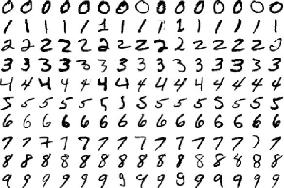

Examples from the MNIST dataset

```r
mnist <- dataset_mnist()
class(mnist)
```

```
## [1] "list"
```

```r
names(mnist)
```

```
## [1] "train" "test"
```

Each image in the dataset is a matrix with dimensions (28, 28, 1), where each pixel corresponds to a value in [0, 255]. We scale the values at each pixel so that they are in the range [0,1]. Then we use the `to_categorical()` function from the `keras` package to transform the vector of labels to a matrix of binary values representing the same categories.

```r
x.train <- mnist$train$x %>%
  array_reshape(c(nrow(mnist$train$x), 28, 28, 1)) %>%
  (function(x){x / 255})

x.test <- mnist$test$x %>%
  array_reshape(c(nrow(mnist$test$x), 28, 28, 1)) %>%
  (function(x){x / 255})

y.train <- mnist$train$y %>%
  to_categorical(10)

y.test <- mnist$test$y %>%
  to_categorical(10)
```

We can create a bar chart to see how the digits are distributed. This gives us an idea of what to expect when we’re evaluating the models.

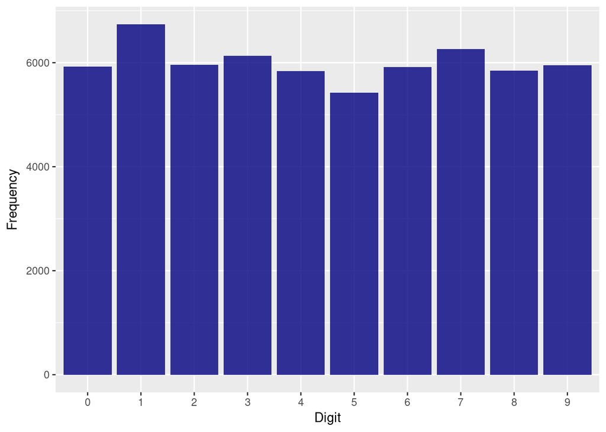

```r
y.table <- mnist$train$y %>%
  table() %>%
  as.data.frame()

colnames(y.table) <- c("digit", "count")

ggplot(y.table, aes(x=digit, y=count)) +
  geom_bar(stat="identity", fill="navyblue", alpha=0.8) +
  labs(
    x="Digit",
    y="Frequency"
  )
```

We also want to make sure that we have no missing data. We run a quick check.

```r
x.train.vec <- x.train %>%
  array_reshape(c(nrow(x.train), 28*28))
sum(complete.cases(x.train.vec)) == nrow(x.train.vec)
```

```
## [1] TRUE
```

Each of the images we are working with can be plotted, to help us better understand the data. The plot below shows the 13th example in the dataset.

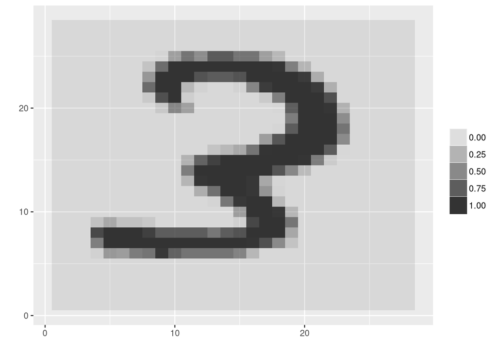

```r
img <- x.train[13, , , ] %>%
  melt()  # make the data play nice with ggplot

ggplot(img, aes(x=Var2, y=Var1, alpha=value)) +
  geom_raster() +
  labs(x="", y="", alpha="")
```

## Split Training and Validation Set

We further split the training set of 60,000 examples into a validation set consisting of 10% of the examples, and the remaining 90% will be the new training set.

```r
set.seed(101)
smp_size <- floor(0.9 * nrow(x.train))
i <- sample(seq_len(nrow(x.train)), size=smp_size)

x <- x.train[i, , , ] %>%
  array_reshape(c(54000, 28, 28, 1))

x.val <- x.train[-i, , , ] %>%
  array_reshape(c(6000, 28, 28, 1))

y <- y.train[i, ]
y.val <- y.train[-i, ]
```

# Model

## Sequential Convolutional Neural Network

The keras API allows us to build the neural network by creating an instance of the sequential model object, and then using keras’s `layer_()` functions. The layers were chosen from an assignment for a Machine Learning course at Carnegie Mellon.

```r
# Create a sequential model
model <- keras_model_sequential()

# Add layers
model %>%
  layer_conv_2d(filters=32, kernel_size=c(5, 5), padding="Same",
                activation="relu", input_shape=c(28, 28, 1)) %>%
  layer_conv_2d(filters=32, kernel_size=c(5, 5), padding="Same",
                activation="relu") %>%
  layer_max_pooling_2d(pool_size=c(2, 2)) %>%
  layer_dropout(rate=0.25) %>%
  layer_conv_2d(filters=32, kernel_size=c(3, 3), padding="Same",
                activation="relu") %>%
  layer_conv_2d(filters=32, kernel_size=c(3, 3), padding="Same",
                activation="relu") %>%
  layer_max_pooling_2d(pool_size=c(2, 2), strides=c(2, 2)) %>%
  layer_dropout(rate=0.25) %>%
  layer_flatten() %>%
  layer_dense(units=256, activation="relu") %>%
  layer_dropout(rate=0.5) %>%
  layer_dense(units=10, activation="softmax")

model %>%
  summary()
```

```
## ___________________________________________________________________________
## Layer (type)                     Output Shape                  Param #
## ===========================================================================
## conv2d_1 (Conv2D)                (None, 28, 28, 32)            832
## ___________________________________________________________________________
## conv2d_2 (Conv2D)                (None, 28, 28, 32)            25632
## ___________________________________________________________________________
## max_pooling2d_1 (MaxPooling2D)   (None, 14, 14, 32)            0
## ___________________________________________________________________________
## dropout_1 (Dropout)              (None, 14, 14, 32)            0
## ___________________________________________________________________________
## conv2d_3 (Conv2D)                (None, 14, 14, 32)            9248
## ___________________________________________________________________________
## conv2d_4 (Conv2D)                (None, 14, 14, 32)            9248
## ___________________________________________________________________________
## max_pooling2d_2 (MaxPooling2D)   (None, 7, 7, 32)              0
## ___________________________________________________________________________
## dropout_2 (Dropout)              (None, 7, 7, 32)              0
## ___________________________________________________________________________
## flatten_1 (Flatten)              (None, 1568)                  0
## ___________________________________________________________________________
## dense_1 (Dense)                  (None, 256)                   401664
## ___________________________________________________________________________
## dropout_3 (Dropout)              (None, 256)                   0
## ___________________________________________________________________________
## dense_2 (Dense)                  (None, 10)                    2570
## ===========================================================================
## Total params: 449,194
## Trainable params: 449,194
## Non-trainable params: 0
## ___________________________________________________________________________
```

## Setting the optimizer

The optimizer is responsible for iteratively improving parameters to minimize the loss function. We choose RMSProp because it is faster than Stochastic Gradient Descent and performs very well on this model. We define the loss function to be categorical cross-entropy, since we are categorizing with more than 2 classes. And lastly, we measure the model’s performance as the proportion of correctly labelled examples, its accuracy.

```r
model %>%
  compile(
    loss="categorical_crossentropy",
    optimizer=optimizer_rmsprop(epsilon=1*exp(-8)),
    metrics=c("accuracy")
)
```

## Setting the learning rate annealer

We set an annealer that makes the optimizer converge faster to the global minimum of the loss function.

```r
lr.reduction <- callback_reduce_lr_on_plateau(monitor="val_acc",
                  patience=3, verbose=1, factor=0.5, min_lr=0.00001)
epochs <- 10
batch_size <-128
```

At this point we could run the model and achieve a very reasonable accuracy: about 97% after 10 epochs. However, we can use data augmentation to artificially expand the dataset.

```r
# To run the model without data augmentation:

# history <- model %>%
#   fit(
#     x, y, epochs=epochs, batch_size=batch_size,
#     validation_data=list(x.val, y.val)
#   )
```

## Data Augmentation

Data Augmentation helps prevent overfitting. We generate new images that are a result of randomly rotating, zooming, and shifting the existing images.

```r
datagen <- image_data_generator(
  featurewise_center=FALSE,
  samplewise_center=FALSE,
  featurewise_std_normalization=FALSE,
  samplewise_std_normalization=FALSE,
  zca_whitening=FALSE,
  rotation_range=10,
  zoom_range=0.1,
  width_shift_range=0.1,
  height_shift_range=0.1,
  horizontal_flip=FALSE,
  vertical_flip=FALSE
)

datagen %>%
  fit_image_data_generator(x)
```

# Evaluating our model

After 10 epochs, we have achieved 99.43% validation accuracy. The validation accuracy is always higher than the training accuracy, so our model is not overfitting.

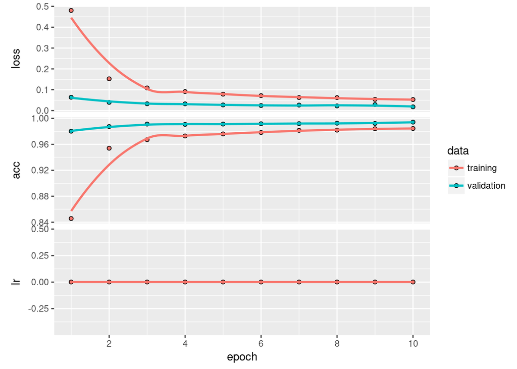

```r
plot(history)
```

```r
model %>%
  evaluate(x.test, y.test)
```

```
## $loss
## [1] 0.01759678
##
## $acc
## [1] 0.9942
```

```r
y.pred <- model %>%
  predict_classes(x.test) %>%
  as.vector()
```

## Confusion Matrix

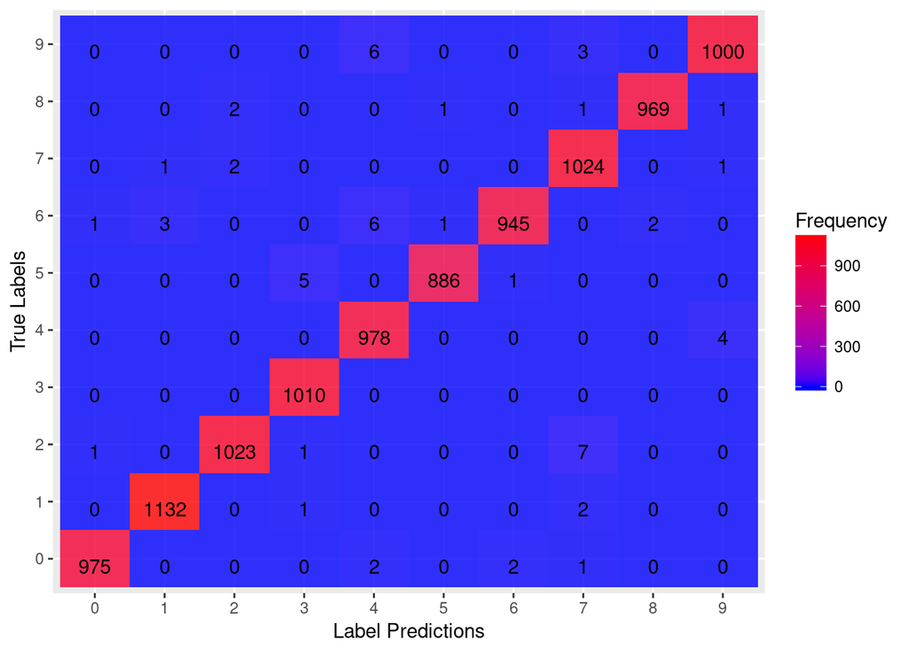

```r
y.true <- mnist$test$y
conf.matrix <- table(y.pred, y.true) %>%
  as.data.frame()

ggplot(conf.matrix, aes(x=y.pred, y=y.true)) +
  geom_tile(aes(fill=Freq), alpha=0.8) +
  geom_text(aes(label=sprintf("%1.0f", Freq)), vjust=1) +
  scale_fill_gradient(low="blue", high="red") +
  labs(
    x="Label Predictions",
    y="True Labels",
    fill="Frequency"
  )
```